# deseq_sailfins

Luke Reding

January 6, 2016

# 1 DESeq2 with sailfin dataset

## 1.1 reading in data

Read in count data. I also get rid of the first column (the genes) and make them the row names, otherwise `DESeq` gets upset:

```r
library(DESeq2)
library(magrittr)

counts <- read.csv("/Users/lukereding/Desktop/molly_arts/counts.tab", sep = "\t", header=FALSE)
head(counts)
```

```
##                                     V1   V2   V3   V4   V5   V6   V7   V8
## 1         ENSPFOG00000016007  ensembl  2529 2920 3098 2600 1778 2569 1948
## 2 ENSPFOG00000016069  TMEM65 (2 of 2)  3742 3218 3702 3165 2794 4026 2769
## 3          ENSPFOG00000016108  mboat1  2129 2117 1963 1464 1076 1609 1260
## 4            ENSPFOG00000016235  e2f3   302  300  395  300  190  259  240
## 5          ENSPFOG00000016282  cdkal1   763  869  765  674  479  776  638
## 6           ENSPFOG00000016372  sox4a   935  686  935  840  497  725  614
##     V9  V10  V11  V12
## 1  962 1849 2398 1511
## 2 2117 2607 2997 2663
## 3  894 1386 1420 1408
## 4  107  263  214  199
## 5  425  612  653  757
## 6  382  519  778  643
```

```r
# save table of gene names and gene IDs
gene_names <- counts[,1] %>% gsub("ENSP.*  ","",.) %>% gsub(" ","",.)
gene_ids <- counts[,1] %>% gsub(" .*","",.) %>% gsub(" ","",.)
write.csv(data.frame(gene_names,gene_ids),"/Users/lukereding/Desktop/molly_arts/gene_names_and_ids.csv", row.names=F)

# some workarounds since the counts are separated by tabs by the gene IDs and gene names are separated by two spaces:
#rownames(counts) <- counts[,1] %>% gsub("ENSP.*  ","",.) %>% gsub(" ","",.)
counts[,1] %<>% gsub(" .*","",.) %>% gsub(" ","",.)

# until I can solve the problem with gene repeats:
rownames(counts) <- counts[,1]
counts <- counts[,-1]

colnames(counts) <- c("SRR1161450_1","SRR1165203_1","SRR1166368_1","SRR1166371_1","SRR1161451_1","SRR1166366_1","SRR1166369_1","SRR1166372_1","SRR1165201_1","SRR1166367_1","SRR1166370_1")

head(counts)
```

```
##                    SRR1161450_1 SRR1165203_1 SRR1166368_1 SRR1166371_1
## ENSPFOG00000016007         2529         2920         3098         2600
## ENSPFOG00000016069         3742         3218         3702         3165
## ENSPFOG00000016108         2129         2117         1963         1464
## ENSPFOG00000016235          302          300          395          300
## ENSPFOG00000016282          763          869          765          674
## ENSPFOG00000016372          935          686          935          840
##                    SRR1161451_1 SRR1166366_1 SRR1166369_1 SRR1166372_1
## ENSPFOG00000016007         1778         2569         1948          962
## ENSPFOG00000016069         2794         4026         2769         2117
## ENSPFOG00000016108         1076         1609         1260          894
## ENSPFOG00000016235          190          259          240          107
## ENSPFOG00000016282          479          776          638          425
## ENSPFOG00000016372          497          725          614          382
##                    SRR1165201_1 SRR1166367_1 SRR1166370_1
## ENSPFOG00000016007         1849         2398         1511
## ENSPFOG00000016069         2607         2997         2663
## ENSPFOG00000016108         1386         1420         1408
## ENSPFOG00000016235          263          214          199
## ENSPFOG00000016282          612          653          757
## ENSPFOG00000016372          519          778          643
```

```r
# save `counts`
write.csv(counts,"/Users/lukereding/Desktop/molly_arts/counts.csv")
```

We have 11 columns in our count dataset, or 11 individuals.

Now I make a dataframe relating sample names to conditions:

```r
male_sizes <- c("intermediate", "intermediate", "small", "small", "intermediate", "intermediate", "small", "small", "intermediate","small", "small")
code <- c("BIA1", "BIM1", "BSA2", "BSM2", "BIA2", "BIM2", "BSA3", "BSM3", "BIA3", "BSA1", "BSM1")
social <- c("alone","multimale", "alone", "multimale", "alone", "multimale", "alone", "multimale", "alone", "alone", "multimale")

## some error checking:
if(length(male_sizes) != (ncol(counts))) stop("recheck male_sizes")
if(length(male_sizes %>% factor %>% levels) != 2) stop("recheck male_sizes")
if(length(code) != (ncol(counts))) stop("recheck code")
if(length(social %>% factor %>% levels) != 2) stop("recheck social")
if(length(social) != (ncol(counts))) stop("recheck social")

conditions <- data.frame(colnames(counts), male_sizes, code, social)
colnames(conditions)[1] <- "sample_names"
conditions %>% print
```

```
##    sample_names   male_sizes code    social
## 1  SRR1161450_1 intermediate BIA1     alone
## 2  SRR1165203_1 intermediate BIM1 multimale
## 3  SRR1166368_1        small BSA2     alone
## 4  SRR1166371_1        small BSM2 multimale
## 5  SRR1161451_1 intermediate BIA2     alone
## 6  SRR1166366_1 intermediate BIM2 multimale
## 7  SRR1166369_1        small BSA3     alone
## 8  SRR1166372_1        small BSM3 multimale
## 9  SRR1165201_1 intermediate BIA3     alone
## 10 SRR1166367_1        small BSA1     alone
## 11 SRR1166370_1        small BSM1 multimale
```

## 1.2 creating the DESeq2 object

Now we construct the main `DESeq` object. The statistical model models the counts as a function of a male’s size, his social treatment, and the interaction between these two (defined in `design = ~ social + male_sizes + social*male_sizes`):

```r
dds <- DESeqDataSetFromMatrix(countData = counts, colData = conditions, design = ~ social + male_sizes + social*male_sizes)

# make sure your treatments are factors
colData(dds)$social %<>% factor
colData(dds)$male_sizes %<>% factor
```

For WGCNA, we’ll need to use a matrix of normalized counts. Let’s go ahead and save this now.

```r
x <- varianceStabilizingTransformation(dds)

write.csv(assay(x),"/Users/lukereding/Desktop/molly_arts/counts_VST.csv")
```

To make sure that are results are interpretable and that we understand the directionality of the differentially expressed genes we find, it is useful to use the `relevel` function to assign one of the factor levels in each treatment as the baseline.

```r
# relevel to make the small male the baseline
colData(dds)$social <- relevel(colData(dds)$social, "alone")
colData(dds)$male_sizes <- relevel(colData(dds)$male_sizes, "small")
```

The main functions:

```r
dds <- DESeq(dds)
res <- results(dds)
res <- res[order(res$padj),]
head(res)
```

```
## log2 fold change (MLE): socialmultimale.male sizesintermediate
## Wald test p-value: socialmultimale.male sizesintermediate
## DataFrame with 6 rows and 6 columns
##                      baseMean log2FoldChange     lfcSE      stat
##                     <numeric>      <numeric> <numeric> <numeric>
## ENSPFOG00000013657  708.54029       2.310902 0.1779276 12.987879
## ENSPFOG00000011773 1281.66554      -3.010149 0.3311618 -9.089662
## ENSPFOG00000005743   75.69948       6.627462 0.9157650  7.237077
## ENSPFOG00000022104  120.05378      11.718424 1.6794492  6.977540
## ENSPFOG00000005683  256.21540       5.455038 0.7895773  6.908808
## ENSPFOG00000006381   39.75933       7.023252 1.0462957  6.712492
##                          pvalue         padj
##                       <numeric>    <numeric>
## ENSPFOG00000013657 1.433455e-38 3.108448e-34
## ENSPFOG00000011773 9.934725e-20 1.077173e-15
## ENSPFOG00000005743 4.584571e-13 3.313881e-09
## ENSPFOG00000022104 3.003934e-12 1.628508e-08
## ENSPFOG00000005683 4.887439e-12 2.119682e-08
## ENSPFOG00000006381 1.913282e-11 5.927075e-08
```

```r
# useful for later
resultsNames(dds)
```

```
## [1] "Intercept"
## [2] "social_multimale_vs_alone"
## [3] "male_sizes_intermediate_vs_small"
## [4] "socialmultimale.male_sizesintermediate"
```

Note that the default for `alpha`–the significance cutoff–used in this function is 0.10. This implies that 10%of the genes that are significant in our analysis are false-positivies. To change this value to something more stringent, use `alpha = X` in the `results` function.

# 2 results

### 2.0.1 summary

Here’s a summary of our results:

```r
summary(res)
```

```
##
## out of 24082 with nonzero total read count
## adjusted p-value < 0.1
## LFC > 0 (up)     : 1948, 8.1%
## LFC < 0 (down)   : 851, 3.5%
## outliers [1]     : 64, 0.27%
## low counts [2]   : 2333, 9.7%
## (mean count < 5)
## [1] see 'cooksCutoff' argument of ?results
## [2] see 'independentFiltering' argument of ?results
```

For a description of what the columns mean:

```r
mcols(res)$description
```

```
## [1] "mean of normalized counts for all samples"
## [2] "log2 fold change (MLE): socialmultimale.male sizesintermediate"
## [3] "standard error: socialmultimale.male sizesintermediate"
## [4] "Wald statistic: socialmultimale.male sizesintermediate"
## [5] "Wald test p-value: socialmultimale.male sizesintermediate"
## [6] "BH adjusted p-values"
```

Differentially expressed genes (based on adjusted p-value):

```r
subset(res, res$padj < 0.05) %>% data.frame %>% head(20)
```

```
##                      baseMean log2FoldChange     lfcSE      stat
## ENSPFOG00000013657  708.54029       2.310902 0.1779276 12.987879
## ENSPFOG00000011773 1281.66554      -3.010149 0.3311618 -9.089662
## ENSPFOG00000005743   75.69948       6.627462 0.9157650  7.237077
## ENSPFOG00000022104  120.05378      11.718424 1.6794492  6.977540
## ENSPFOG00000005683  256.21540       5.455038 0.7895773  6.908808
## ENSPFOG00000006381   39.75933       7.023252 1.0462957  6.712492
## ENSPFOG00000001955  995.86740       3.474999 0.5173131  6.717400
## ENSPFOG00000018748   55.45634       6.943645 1.0474429  6.629140
## ENSPFOG00000020847  365.16344      10.868126 1.6303492  6.666134
## ENSPFOG00000011100  420.46229       4.458581 0.6710324  6.644360
## ENSPFOG00000004625  103.46899       5.713861 0.8632081  6.619331
## ENSPFOG00000001001   70.48828       6.139489 0.9342974  6.571236
## ENSPFOG00000019505 1187.68657       2.915417 0.4441564  6.563943
## ENSPFOG00000024766  546.35004      13.431123 2.0449030  6.568098
## ENSPFOG00000022566  256.31957       8.677957 1.3259980  6.544472
## ENSPFOG00000017642 1449.09026       3.064046 0.4684633  6.540632
## ENSPFOG00000009066 5155.14219       2.057970 0.3155120  6.522637
## ENSPFOG00000010722  208.70340       4.192353 0.6480321  6.469360
## ENSPFOG00000008424   46.26231       7.348983 1.1340053  6.480554
## ENSPFOG00000023058  926.79544       8.090229 1.2491222  6.476732
##                          pvalue         padj
## ENSPFOG00000013657 1.433455e-38 3.108448e-34
## ENSPFOG00000011773 9.934725e-20 1.077173e-15
## ENSPFOG00000005743 4.584571e-13 3.313881e-09
## ENSPFOG00000022104 3.003934e-12 1.628508e-08
## ENSPFOG00000005683 4.887439e-12 2.119682e-08
## ENSPFOG00000006381 1.913282e-11 5.927075e-08
## ENSPFOG00000001955 1.849960e-11 5.927075e-08
## ENSPFOG00000018748 3.376481e-11 7.113210e-08
## ENSPFOG00000020847 2.626293e-11 7.113210e-08
## ENSPFOG00000011100 3.045372e-11 7.113210e-08
## ENSPFOG00000004625 3.608269e-11 7.113210e-08
## ENSPFOG00000001001 4.989936e-11 8.116897e-08
## ENSPFOG00000019505 5.240330e-11 8.116897e-08
## ENSPFOG00000024766 5.096215e-11 8.116897e-08
## ENSPFOG00000022566 5.970596e-11 8.302543e-08
## ENSPFOG00000017642 6.125925e-11 8.302543e-08
## ENSPFOG00000009066 6.908169e-11 8.811979e-08
## ENSPFOG00000010722 9.841889e-11 1.067107e-07
## ENSPFOG00000008424 9.138654e-11 1.067107e-07
## ENSPFOG00000023058 9.373075e-11 1.067107e-07
```

There are 2058 differentially expressed genes.

Plot some results:

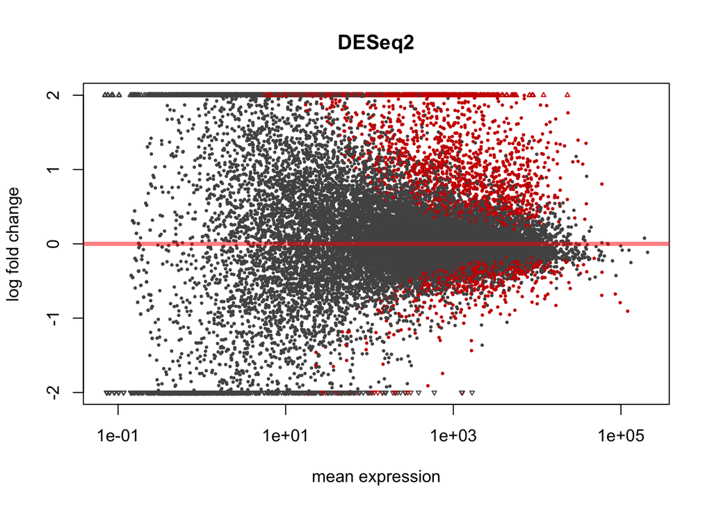

```r
plotMA(dds,ylim=c(-2,2),main="DESeq2")
```

## 2.1 finding differentially expressed genes for our different factors

One thing we might be interested in doing is finding out what genes are significantly differently expressed by male size, social treatment, and their interaction.

But default, when you print your results, as we did with `head(res)` above, DESeq2 prints the p-values for whatever came last in your model statement–in our case, the interaction between male size and social treatment. We want to be able to create a similar data but populated with the log2-fold changes and p-values associated with a single factor. For example, we might want to know what genes are significantly differently expressed between small and intermediate males while controlling for social treatment. These are the genes significant for the factor `male_sizes` (and, technically, not also significant for the interaction).

To generate data frames with genes that are significant for size and social status, we add some arguments to the `results` function. To get the p-values and log fold changes for genes that are differentially expressed by size, the code ends up looking something like `results(dds, contrast=c("male_sizes","intermediate","small"))`. The `contrast` arugment takes a vector with three elements: the name of the factor, the level of the factor you want to use as the numerator in the log2-fold changes, and the level of the factor you want to be used as the denominator in the same.

Note that extracting the results for continuous variables or interaction terms is done differenly. For how to do these, see my example below.

### 2.1.1 genes that are differentially expressed based on male size

```r
res.size <- results(dds, contrast=c("male_sizes","intermediate","small"))
sum(res.size$padj < 0.05, na.rm=T)
```

```
## [1] 1088
```

```r
# creating a data of just the FDR-corrected significant genes
male_size_table <- subset(res.size, res.size$padj < 0.05)

# save the data as a csv file
write.csv(as.data.frame(male_size_table),file="/Users/lukereding/Desktop/molly_arts/male_size_significant_genes.csv")
```

So there are 1088 genes are differentially expressed based on male size.

### 2.1.2 genes that are differentially expressed based on social treatment

```r
res.social <- results(dds, contrast=c("social","multimale","alone"))
sum(res.social$padj < 0.05, na.rm=T)
```

```
## [1] 751
```

```r
# creating a data of just the FDR-corrected significant genes
social_table <- subset(res.social, res.social$padj < 0.05)

# save the data as a csv file
write.csv(as.data.frame(social_table),file="/Users/lukereding/Desktop/molly_arts/social_treatment_significant_genes.csv")
```

There are 751 genes that are significantly differently expressed by social treatment.

### 2.1.3 genes that are differentially expressed based on male size * social treatment interaction

Look at genes significant for interaction:

```r
res.interaction <- results(dds, independentFiltering = FALSE, name = "socialmultimale.male_sizesintermediate")
table(res.interaction$padj < 0.05)
```

```
##
## FALSE  TRUE
## 22032  1986
```

```r
interaction_table <- subset(res.interaction, res.interaction$padj < 0.05)

# save the data as a csv file
write.csv(as.data.frame(interaction_table),file="/Users/lukereding/Desktop/molly_arts/interaction_significant_genes.csv")
```

## 2.2 plotting results from individual genes

For example, if we wanted to visualize the difference in counts between small and intermediate fish for the gene with the smallest p-value, we could use

```r
require(viridis)
```

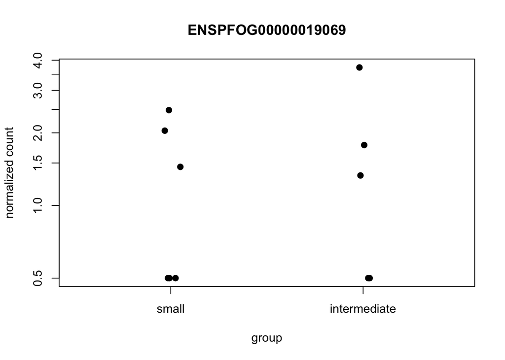

```r
plotCounts(dds, gene=which.min(male_size_table$padj), intgroup="male_sizes", pch=16, cex=1.2)
```

The results for this gene are surprisingly not clear cut and seem to be driven by the two “outlier” data points in the small group.

Let’s pick a different gene:

```r
x <- plotCounts(dds, gene=100, intgroup="male_sizes", pch=16, cex=1.2, returnData = T)
```

Plotting things the way I like them:

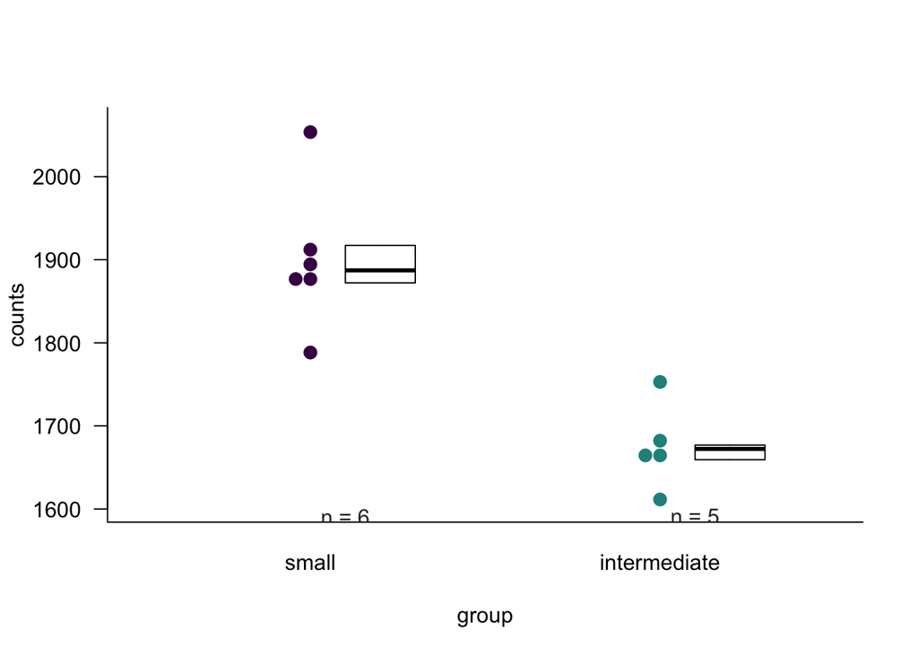

```r
require(redingPlot)
beeStripBox(x$count, x$male_sizes, stats = F, ylab="counts")
```

## 2.3 other visualizations

From pg 21 -22 of tutorial:

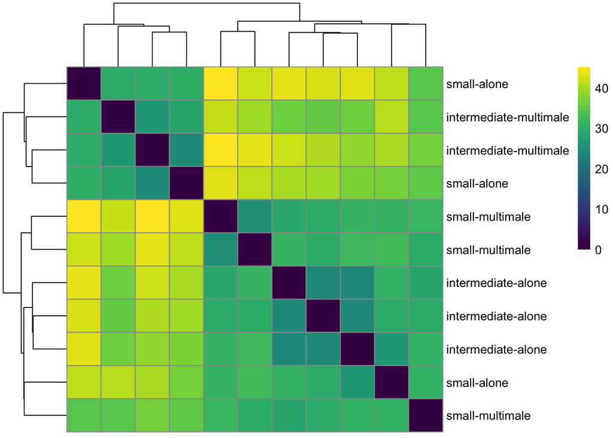

```r
require(pheatmap)
# apply a log transformation to the counts
rld <- rlog(dds)

# create a distance matrix
sampleDists <- dist(t(assay(rld)))
sampleDistMatrix <- as.matrix(sampleDists)

# change rownames
rownames(sampleDistMatrix) <- paste(rld$male_sizes, rld$social, sep="-")
colnames(sampleDistMatrix) <- NULL

# create a heatmap
pheatmap(sampleDistMatrix, clustering_distance_rows=sampleDists, clustering_distance_cols=sampleDists, col=viridis(100))
```

This heatmap doesn’t make a whole lot of sense: fish with similar properties (size class and social treatment) don’t really group together.

This is doubly reflected in the PCA plot:

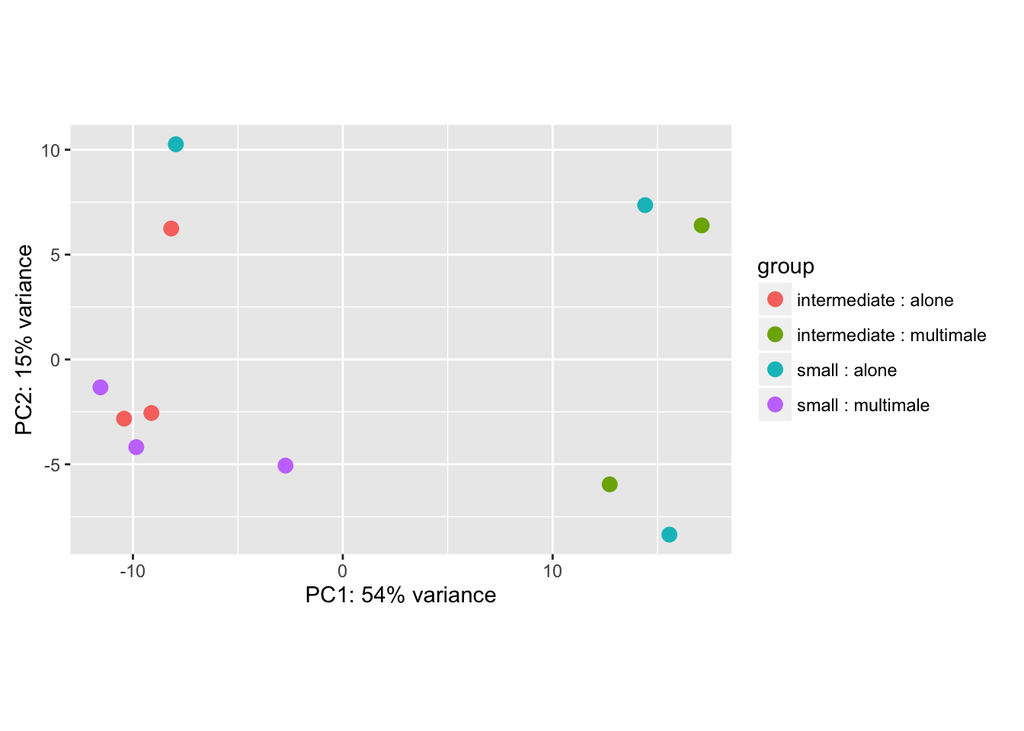

```r
plotPCA(rld, intgroup=c("male_sizes", "social"))
```

# 3 using WGCNA

This code is based off the WGCNA tutorials for R that can be found [here](https://labs.genetics.ucla.edu/horvath/CoexpressionNetwork/Rpackages/WGCNA/Tutorials/).

```r
# load in the data
data <- read.csv("/Users/lukereding/Desktop/molly_arts/counts_VST.csv")
head(data)
```

```
##                    X        X1        X2        X3        X4        X5
## 1 ENSPFOG00000016007 11.152533 11.378643 11.356774 11.289526 11.293290
## 2 ENSPFOG00000016069 11.670028 11.507304 11.593026 11.549486 11.896527
## 3 ENSPFOG00000016108 10.930800 10.960593 10.768618 10.557995 10.650741
## 4 ENSPFOG00000016235  8.817884  8.836679  9.010657  8.877833  8.815169
## 5 ENSPFOG00000016282  9.711552  9.886736  9.663932  9.661177  9.705716
## 6 ENSPFOG00000016372  9.936479  9.628425  9.883867  9.902844  9.745781
##          X6        X7        X8        X9       X10       X11
## 1 11.352767 11.249394 10.764694 11.164970 11.288302 10.756034
## 2 11.954228 11.715936 11.796007 11.618252 11.583356 11.489529
## 3 10.750189 10.691893 10.672930 10.795696 10.619039 10.667719
## 4  8.804326  8.907983  8.523240  8.977374  8.665661  8.646072
## 5  9.881410  9.883789  9.796875  9.823481  9.713215  9.929377
## 6  9.805896  9.841050  9.680735  9.644218  9.906514  9.748267
```

```r
gene_names <- data[,1]
data <- data[,-1]

# for some reason, WGCNA wants to data frame with the rows as individuals and the columns as genes
# so we transpose the dataframe
data<-t(data)
rownames(data) <- c("SRR1161450_1","SRR1165203_1","SRR1166368_1","SRR1166371_1","SRR1161451_1","SRR1166366_1","SRR1166369_1","SRR1166372_1","SRR1165201_1","SRR1166367_1","SRR1166370_1")
colnames(data) <- gene_names
data[1:11,1:5]
```

```
##              ENSPFOG00000016007 ENSPFOG00000016069 ENSPFOG00000016108
## SRR1161450_1           11.15253           11.67003           10.93080
## SRR1165203_1           11.37864           11.50730           10.96059
## SRR1166368_1           11.35677           11.59303           10.76862
## SRR1166371_1           11.28953           11.54949           10.55799
## SRR1161451_1           11.29329           11.89653           10.65074
## SRR1166366_1           11.35277           11.95423           10.75019
## SRR1166369_1           11.24939           11.71594           10.69189
## SRR1166372_1           10.76469           11.79601           10.67293
## SRR1165201_1           11.16497           11.61825           10.79570
## SRR1166367_1           11.28830           11.58336           10.61904
## SRR1166370_1           10.75603           11.48953           10.66772
##              ENSPFOG00000016235 ENSPFOG00000016282
## SRR1161450_1           8.817884           9.711552
## SRR1165203_1           8.836679           9.886736
## SRR1166368_1           9.010657           9.663932
## SRR1166371_1           8.877833           9.661177
## SRR1161451_1           8.815169           9.705716
## SRR1166366_1           8.804326           9.881410
## SRR1166369_1           8.907983           9.883789
## SRR1166372_1           8.523240           9.796875
## SRR1165201_1           8.977374           9.823481
## SRR1166367_1           8.665661           9.713215
## SRR1166370_1           8.646072           9.929377
```

Do some basic pre-processing:

```r
require(WGCNA)
allowWGCNAThreads()
```

```
## Allowing multi-threading with up to 4 threads.
```

```r
gsg = goodSamplesGenes(data, verbose = 3)
```

```
##  Flagging genes and samples with too many missing values...
##   ..step 1
##   ..Excluding 272 genes from the calculation due to too many missing samples or zero variance.
##   ..step 2
```

```r
gsg$allOK
```

```
## [1] FALSE
```

If returns TRUE, then there are not too many samples with missing data. That’s not the case for our data. This means that some of our genes have zero variance, which are uninformative and will mess things up later on.

To visalize an example of one of these genes:

```r
i <- which(!gsg$goodGenes)[1]
data[,i]
```

```
## SRR1161450_1 SRR1165203_1 SRR1166368_1 SRR1166371_1 SRR1161451_1
##     6.899717     6.899717     6.899717     6.899717     6.899717
## SRR1166366_1 SRR1166369_1 SRR1166372_1 SRR1165201_1 SRR1166367_1
##     6.899717     6.899717     6.899717     6.899717     6.899717
## SRR1166370_1
##     6.899717
```

Here we see that all the value for this gene are the same 6.9: there is no variance. So this is what the genes we’re removing looks like.

Let’s remove them:

```r
if (!gsg$allOK)
{
# Optionally, print the gene and sample names that were removed:
if (sum(!gsg$goodGenes)>0)
printFlush(paste("Removing genes:", paste(names(data)[!gsg$goodGenes], collapse = ", ")));
if (sum(!gsg$goodSamples)>0)
printFlush(paste("Removing samples:", paste(rownames(data)[!gsg$goodSamples], collapse = ", ")));
# Remove the offending genes and samples from the data:
data = data[gsg$goodSamples, gsg$goodGenes]
}
```

```
## Removing genes:
```

```r
gsg = goodSamplesGenes(data, verbose = 3)
```

```
##  Flagging genes and samples with too many missing values...
##   ..step 1
```

Now when we run `gsg$allOK`, it should return TRUE: TRUE.

Now we cluster the sample the ensure there are no obvious outliers:

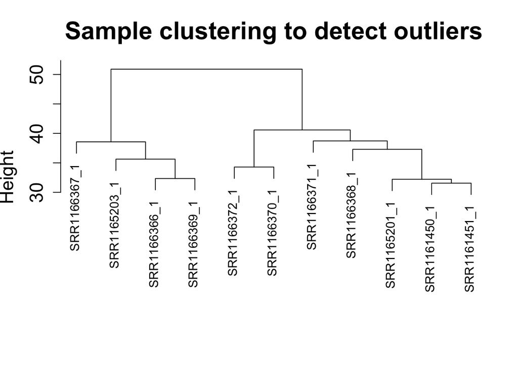

```r
sampleTree = hclust(dist(data), method = "average")

plot(sampleTree, main = "Sample clustering to detect outliers", sub="", xlab="", cex.lab = 1.5,cex.axis = 1.5, cex.main = 2)
```